# Week3

Sebastian Hoyos-Torres

9/12/2018

# Chapter 3

## Section 1

### Question 6

Possible X values are

$X = \{1,2,3,4,...\}$

and 5 possible outcomes are:

$X(L) = 1, X(AL)= 2, X(AARRL) = 5, X(RL) = 2, X(AAAL) = 4$

### Question 10

For the number of pumps in use at the station, we can simply do the following.

Part A

$T = \{0,1,2,3,4,5,6,7,8,9,10\}$

Part B (just subtract station 1’s pumps in use from station 2’s)

$X = \{-4,-3,-2,-1,0,1,2,3,4,5,6\}$

##Section 2

### Question 12

We can do this in R or do this manually. I will show everyone the R code as follows

```r
#make a dataframe or tibble of values
pmfy <- tibble(y = 45:55,py = c(0.05,0.1,0.12,.14,.25,.17,.06,.05,.03,.02,.01))
```

Part A is asking for the first 50 ticketed passengers so

```r
pmfyfilt<- pmfy %>% filter(y <= 50)
sum(pmfyfilt$py)
```

```
## [1] 0.83
```

Part B is asking for the probability that not all ticketed passengers can be accomodated. So the probability for people from 51 onwards (or $P(Y>50)$)

```r
pmfyfilt<- pmfy %>% filter(y >= 51)
sum(pmfyfilt$py)
```

```
## [1] 0.17
```

Part C is two parts but in R, this is done in a pretty similar manner

```r
# if you're the first person on the waiting list you need person 50 to drop so
pmfyfilt<- pmfy %>% filter(y <= 49)
sum(pmfyfilt$py) #solution to first part
```

```
## [1] 0.66
```

```r
# if you're 3rd you need persons 47-50 to drop
pmfyfilt<- pmfy %>% filter(y <= 47)
sum(pmfyfilt$py)
```

```
## [1] 0.27
```

### Question 13

Let’s set this table up in R as a tibble

```r
pmfx <- tibble(x = 0:6, px = c(seq(.1,.25,by = .05),.2,.06,.04))
```

Part A is asking for $P(X = x \leq 3)$

```r
pmfxfilt <- pmfx %>% filter(x <= 3)
sum(pmfxfilt$px)
```

```
## [1] 0.7
```

Part B is asking for $P(X = x < 3)$

```r
pmfxfilt <- pmfx %>% filter(x < 3)
sum(pmfxfilt$px)
```

```
## [1] 0.45
```

Part C is asking for $p(x \geq 3)$

```r
pmfxfilt <- pmfx %>% filter(x >= 3)
sum(pmfxfilt$px)
```

```
## [1] 0.55
```

Part D gets a little trickier but is asking for $1 - p(2\leq{x}\leq{5}$

```r
pmfxfilt <- pmfx %>% filter(x >= 2 &x <= 5)
sum(pmfxfilt$px)
```

```
## [1] 0.71
```

Part E is similar but 4 lines instead and its asking about lines **not in use**. Working this out we find that that if 4 lines are not in use, then 2 are is use, if 3,3 lines in use and if 2, 4 are in use so in this case we can do the same type of filtering

```r
pmfxfilt <- pmfx %>% filter(x >= 2 & x <= 4)
sum(pmfxfilt$px)
```

```
## [1] 0.65
```

Part F is a little different. If at least 4 are not in use then there can be 0-2 lines in use inclusive

```r
pmfxfilt <- pmfx %>% filter(x >= 0 & x <= 2)
sum(pmfxfilt$px)
```

```
## [1] 0.45
```

### Question 14

Looking at this problem, we are just solving for k in the first part while substituting for y so you’d get $k[1+2+3+4+5] = 1$
$$k[15] = 1$$
$$k = \frac{1}{15}$$

```r
1/sum(1:5) #or 1/15
```

```
## [1] 0.06666667
```

```r
1/15
```

```
## [1] 0.06666667
```

For part B we need at most three forms so lets create a tibble.

```r
pmfy <- tibble(y = 1:5, py = (1/15)*y)
pmfyfilt <- pmfy %>% filter(y <= 3)
sum(pmfyfilt$py)
```

```
## [1] 0.4
```

Part C is similar

```r
pmfyfilt <- pmfy %>% filter(y >= 2 & y <= 4)
sum(pmfyfilt$py)
```

```
## [1] 0.6
```

Part D is no since the values do not equal 1 if we substitute with the new py. Remember, the sum of all the probabilities must equal 1

```r
newpmfy<- pmfy %>% mutate(py2 = y^2/50)
sum(newpmfy$py2) == 1
```

```
## [1] FALSE
```

### Question 16

To denote the probability distribution of X where 4 people are randomly selected, we can do the following in R

```r
#first is p(0)
.65^4
```

```
## [1] 0.1785063
```

```r
#next is (think of the possible arrangements with 3 failures)
4*(.75^3*.25)
```

```
## [1] 0.421875
```

```r
#next is p(2)(think of possible permutations with 2 failures)
6*(.75^2 * .25^2)
```

```
## [1] 0.2109375
```

```r
#afterwards, p(3)
4*(.75 *.25^3)
```

```
## [1] 0.046875
```

```r
# finally
.25^4
```

```
## [1] 0.00390625
```

If we just store our results, we could just get R to plot things for us

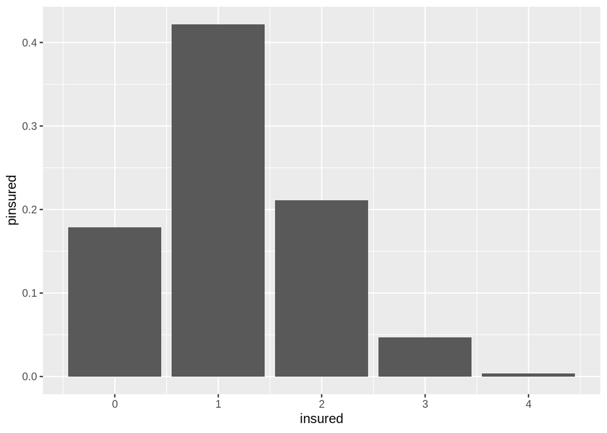

```r
pinsurance <- tibble(insured = 0:4, pinsured = c(.65^4
,4*(.75^3*.25)
,6*(.75^2 * .25^2)
,4*(.75 *.25^3)
,.25^4))
pinsurance %>%
  ggplot(aes(insured,pinsured))+
  geom_histogram(stat = "identity")
```

If we did part 2 ok, we should see that seeing 1 person insured is the most likely value of X. Part D is just using R as we already have to filter x values in the range.

```r
pinsurance %>%
  filter(insured >= 2) %>%
  summarise(pinsurednew = sum(pinsured))
```

```
## # A tibble: 1 x 1
##   pinsurednew
##         <dbl>
## 1       0.262
```

### Question 18

This question is interesting because it asks us to focus on the maximum. In this case, just think of the number of tosses and apply the classical approach to probability

```r
1/36 #one way to get a max of 1 which is (1,1)
```

```
## [1] 0.02777778
```

```r
3/36 #3 ways to get a max of 2 (2,1),(1,2),(2,2)
```

```
## [1] 0.08333333
```

```r
5/36 #5 ways to get a max of 3 (1,3),(2,3)(3,3)(3,2)(3,1)
```

```
## [1] 0.1388889
```

```r
7/36 #7 ways to get a max of 4
```

```
## [1] 0.1944444
```

```r
9/36 #9 ways to get a max of 5
```

```
## [1] 0.25
```

```r
11/36 # 11 ways to get a max of 6
```

```
## [1] 0.3055556
```

```r
# if you noted the pattern early on, you could just use :
seq(1,11,by = 2)/36
```

```
## [1] 0.02777778 0.08333333 0.13888889 0.19444444 0.25000000 0.30555556
```

For the cdf of x, we can make a tibble to solve this

```r
dice <- tibble(x = 1:6,px = seq(1,11,by = 2)/36,cdfx = cumsum(px))
dice
```

```
## # A tibble: 6 x 3
##       x     px   cdfx
##   <int>  <dbl>  <dbl>
## 1     1 0.0278 0.0278
## 2     2 0.0833 0.111
## 3     3 0.139  0.25
## 4     4 0.194  0.444
## 5     5 0.25   0.694
## 6     6 0.306  1
```

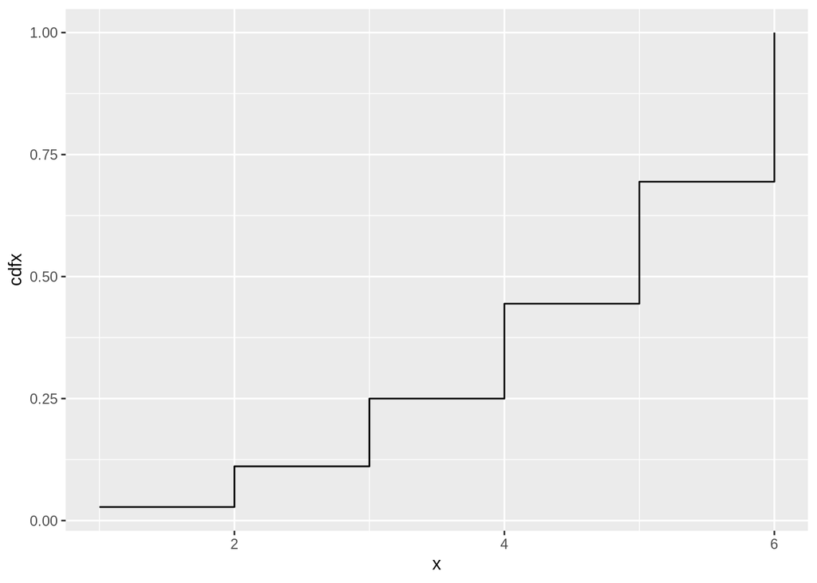

```r
dice %>%
  ggplot(aes(x,cdfx))+
  geom_step()
```

## Section 3

### Question 29

Question 29 is where we can put our defining functions in R skills to use. But first, let’s make a tibble

```r
memoryx <- tibble(x = c(1,2,4,8,16), px = c(.05,.1,.35,.4,.1))
expectedval <- function(x,px){
  sum(x*px)
}
expectedval(memoryx$x,memoryx$px)
```

```
## [1] 6.45
```

Part B is just looking at the formula and trying to replicate it in R. Remember the formula for the variance is $V(X) = \Sigma_D(x-\mu)^2*p(x)$ . In R, it would appear as follows

```r
variancex <- function(x,mu,px){
  sum((x-mu)^2*px)
}
variancex(memoryx$x,expectedval(memoryx$x,memoryx$px), memoryx$px)
```

```
## [1] 15.6475
```

the standard deviation is the square root of the variance

```r
sqrt(variancex(memoryx$x,expectedval(memoryx$x,memoryx$px), memoryx$px))
```

```
## [1] 3.955692
```

### Question 30

This problem is similar to the prior one and now that we have defined a function for the expected value and the variance, we can compute the expected value easily in R. First, create your tibbles.

```r
violations <- tibble(y = 0:3,py = c(.6,.25,.1,.05))
expectedval(violations$y,violations$py)
```

```
## [1] 0.6
```

and the 100 in this case is just a constant that we can multiply by as follows.

```r
100 *expectedval(violations$y^2,violations$py) #don't forget to square the Y
```

```
## [1] 110
```

### Question 32

As is usually the case, it’s best to start off with a tibble for R and we can just apply the function we built.

```r
freezer <- tibble(x = c(13.9,15.9,19.1),px = c(.2,.5,.3))
expectedval(freezer$x,freezer$px) #expected value
```

```
## [1] 16.46
```

```r
expectedval(freezer$x^2,freezer$px) #expected value x^2
```

```
## [1] 274.49
```

```r
variancex(freezer$x, expectedval(freezer$x,freezer$px),freezer$px)#variance
```

```
## [1] 3.5584
```

Part B is just using the expected value within the function

```r
25*expectedval(freezer$x,freezer$px)-8.5
```

```
## [1] 403
```

the variance is

```r
25^2 *3.5584
```

```
## [1] 2224
```

and part d is

```r
sum((freezer$x - 0.01*freezer$x^2)*freezer$px)
```

```
## [1] 13.7151
```